# Univariate Plots Section

### Total sulfur dioxide 、Residual sugar 和 Density

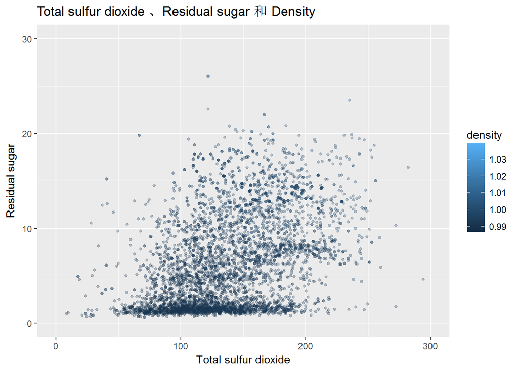

上图揭示了密度与残留糖分以及总 SO2 的关系。残留糖分和总 SO2呈正相关，残留糖分和密度正相关，总 SO2也和密度呈正相关。

# Multivariate Analysis

### Talk about some of the relationships you observed in this part of the investigation. Were there features that strengthened each other in terms of looking at your feature(s) of interest?

影响质量的主要因素是酒精浓度，而酒精浓度又和密度、残留糖分和总二氧化硫浓度密切相关。

### Were there any interesting or surprising interactions between features?

有趣的发现是，酒精浓度、密度、残留糖分、总二氧化硫浓度这四个变量是两两互相关联的，随便抽出两个就有高度相关性。  
我对于此现象的解释是，总二氧化硫的含量会抑制微生物活动，从而会抑制糖转化为酒精的过程，而糖和酒精的含量对于葡萄酒的密度又有直接的影响。因此这四个变量会有高度相关性。

### OPTIONAL: Did you create any models with your dataset? Discuss the strengths and limitations of your model.

# Final Plots and Summary

### Plot One

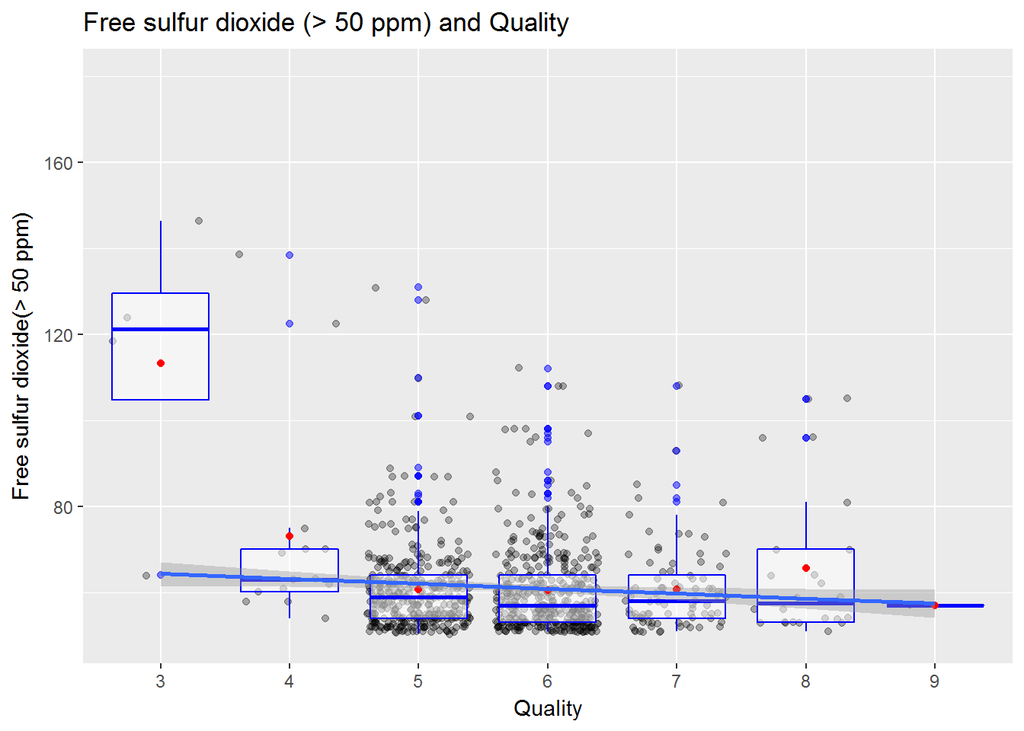

### Plot Two

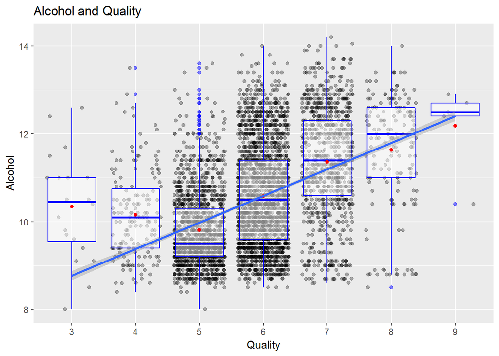

### Description Two

此图整合了 Quality 和 Alcohol 两个变量的散点图和箱线图，反映了Quality 和 Alcohol 之间高度正相关关系，暗示酒精浓度可能是衡量白葡萄酒质量的重要指标。

### Plot Three

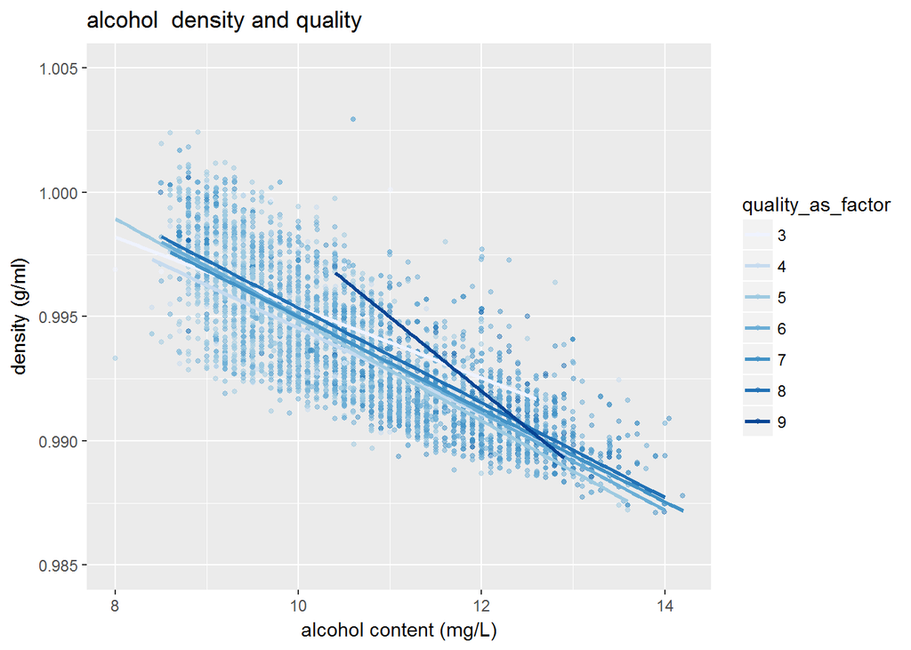

### Description Three

此图包含了 Alcohol、Density 和 Quality 三个变量。从图中可以观察出，Alcohol、Density 呈负相关关系，即酒精浓度越高，密度越小。同时可以观察到，高质量的葡萄酒集中在图的右下角区域，低质量的集中在左上角区域，表明葡萄酒质量与酒精浓度呈正相关，与密度呈负相关。

# Reflection

### 1. 我在分析中的哪个阶段遇到了困难？

我在筛选合适的数据，去除异常值的阶段遇到了困难，比如排除异常值的标准是什么？排除异常值如何进行操作？这个问题没有很好地解决。

### 2. 我在哪个阶段取得了成功？

我在探索性数据分析阶段找出了 Quality 和 Alcohol 的正相关关系、Quality 和 Free sulfur dioxide(> 50 ppm) 的负相关关系； 发现酒精浓度、密度、残留糖分、总二氧化硫浓度这四个变量是两两互相关联的，并尝试解释。

### 3. 将来工作中还可以通过哪些方式使分析更丰富（如：附加数据和分析）？

我注意到除了此白葡萄酒数据集外，还有一个红葡萄酒数据集。我想将这两个数据集进行对比分析，一定可以得出一些有趣的结论。